title: “PAC2” author: “Carlos A. García” date: “November 11, 2019” output: pdf_document —Les dades, exploració

## Títol de la visualització on és presenten el dataset o datasets escollits

Diferències salarials per sexe i per lloc de feina

## Descripció curta del document i del que s’hi presenta

Les dades mostren les diferències salarials entre homes i dones per a un mateix lloc de feina i categoria laboral. Les dades estan detallades per país (Estats Units i Regne Unit) i agrupades per categoria laboral.

Els valors estan especificats en la moneda local (Dólars per a les dades dels EUA i Lliures Esterlines per a les del RU); una petita dificultat afegida és convertir a una única moneda; en el nostre cas, Euros. Les dades són de 2014 i estan extretes del “Bureau of Labor Statistics” (Estats Units) i de la “Office for National Statistics” (Regne Unit).

Les dades són per a empleats a temps complet; no s’inclouen ni els treballadors a temps parcial ni els freelance. Els valors monetaris es corresponen amb mitges anuals.

Les dades originals es poden trobar a la web.

## Les dades, procediment i eines. Explicar com ho heu descobert: amb quines eines, amb quines operacions

### Lectura i tractament inicial de les dades

Carreguem les dades del dataset original (incorporant les variables de país i moneda)

```r
salaryGap <- read.csv2("salaryGap.csv", header = TRUE, sep = ",", dec = ".")
```

Canviem el nom de les columnes a un més adient. Les originals incorporen símbols extranys.

```r
names(salaryGap)[names(salaryGap) == "ï..Occupation"] <- "Occupation"
names(salaryGap)[names(salaryGap) == "Women.average.annual.salary...."] <-
  "WomenAverageAnnualSalary"
names(salaryGap)[names(salaryGap) == "Men.average.annual.salary...."] <-
  "MenAverageAnnualSalary"
names(salaryGap)[names(salaryGap) == "Pay.gap...."] <- "PayGap"
names(salaryGap)[names(salaryGap) == "Pay.gap.as.a.percentage"] <-
  "PayGapAsAPercentage"
salaryGap["WomenAverageAnnualSalaryEUR"] <- salaryGap["WomenAverageAnnualSalary"]
```

Calculem les columnes en EUR (no és possible comparar diferentes monedes)

```r
chageUSDEUR = 0.91
chageUKPEUR = 1.17

salaryGap$WomenAverageAnnualSalaryEUR[salaryGap$Currency == "USD"] <-
  salaryGap$WomenAverageAnnualSalary[salaryGap$Currency == "USD"] * chageUSDEUR

salaryGap$WomenAverageAnnualSalaryEUR[salaryGap$Currency == "UKP"] <-
  salaryGap$WomenAverageAnnualSalary[salaryGap$Currency == "UKP"] * chageUKPEUR

salaryGap$MenAverageAnnualSalaryEUR[salaryGap$Currency == "USD"] <-
  salaryGap$MenAverageAnnualSalary[salaryGap$Currency == "USD"]  * chageUSDEUR

salaryGap$MenAverageAnnualSalaryEUR[salaryGap$Currency == "UKP"] <-
  salaryGap$MenAverageAnnualSalary[salaryGap$Currency == "UKP"] * chageUKPEUR

salaryGap$salaryGapEUR <-
  salaryGap$MenAverageAnnualSalaryEUR - salaryGap$WomenAverageAnnualSalaryEUR

salaryGapUS <- filter(salaryGap, Country == "US")
salaryGapUK <- filter(salaryGap, Country == "UK")
```

Validem que no hi ha nulls:

```r
sum(is.na(salaryGap$WomenAverageAnnualSalaryEUR))
```

```
## [1] 0
```

```r
sum(is.na(salaryGap$MenAverageAnnualSalaryEUR))
```

```
## [1] 0
```

```r
sum(is.na(salaryGap$salaryGapEUR))
```

```
## [1] 0
```

```r
sum(is.na(salaryGap$PayGapAsAPercentage))
```

```
## [1] 0
```

Contem el nombre de registres::

### Resum de les dades

```r
# Total
nrow(salaryGap)
```

```
## [1] 379
```

```r
# Registres RU
nrow(salaryGapUK)
```

```
## [1] 237
```

```r
# Registres EUA
nrow(salaryGapUS)
```

```
## [1] 142
```

Mostrem els resums de les variables numèriques en EUR

```r
summary(salaryGap$WomenAverageAnnualSalaryEUR)
```

```
##    Min. 1st Qu.  Median    Mean 3rd Qu.    Max.
##    2692   21810   30075   31841   39654   90003
```

```r
summary(salaryGap$MenAverageAnnualSalaryEUR)
```

```
##    Min. 1st Qu.  Median    Mean 3rd Qu.    Max.
##    3766   26679   36152   39465   48205  106281
```

```r
summary(salaryGap$salaryGapEUR)
```

```
##    Min. 1st Qu.  Median    Mean 3rd Qu.    Max.
##   -3921    3966    6559    7624   10066   38692
```

```r
summary(salaryGap$PayGapAsAPercentage)
```

```
##    Min. 1st Qu.  Median    Mean 3rd Qu.    Max.
## -0.1153  0.1520  0.2257  0.2524  0.3392  0.8716
```

Mostrem els resums de les variables alfanumèriques

```r
summary(salaryGap$Currency)
```

```
## UKP USD
## 237 142
```

```r
summary(salaryGap$Country)
```

```
##  UK  US
## 237 142
```

```r
head(summary(salaryGap$Occupation), 10)
```

```
##               Admin        Construction Protective services
##                   3                   3                   3
##         Accountants        Arts & media              Bakers
##                   2                   2                   2
##    Care & education            Cashiers     Civil engineers
##                   2                   2                   2
##               Cooks
##                   2
```

```r
summary(salaryGap$Category)
```

```
##        admin & organisation            care & education
##                          29                          48
##            creative & media               law & justice
##                          15                          20
##                 manual work      sales & serving others
##                          40                         102
## science, tech & engineering     senior managers & execs
##                          72                          53
```

Gràficament, als boxplots, es veu clarament que els homes cobren més que les dones

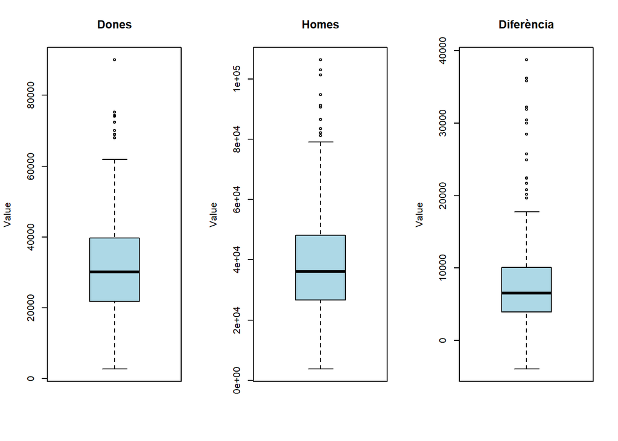

```r
par(mfrow=c(1,3))
boxplot(salaryGap$WomenAverageAnnualSalaryEUR,
                                         main="Dones", xlab="", ylab="Value", col="#ADD8E6")
boxplot(salaryGap$MenAverageAnnualSalaryEUR,
                                       main="Homes", xlab="", ylab="Value", col="#ADD8E6")
boxplot(salaryGap$salaryGapEUR,
                          main="Diferència", xlab="", ylab="Value", col="#ADD8E6")
```

Mostrem els outliers:

```r
boxplot.stats(salaryGap$WomenAverageAnnualSalaryEUR)$out
```

```
## [1] 75238.80 90002.64 68945.24 72352.28 74387.04 70049.07 74093.76 68006.25
## [9] 69086.16
```

```r
boxplot.stats(salaryGap$MenAverageAnnualSalaryEUR)$out
```

```
##  [1]  86453.64  94734.64  83519.80  90617.80 102968.32  82147.52  83425.16
##  [8] 106280.72  91289.25  81217.89 101264.67
```

```r
boxplot.stats(salaryGap$salaryGapEUR)$out
```

```
##  [1] 24937.64 35773.92 36152.48 22429.68 19623.24 29953.56 22382.36
##  [8] 25742.08 31893.68 20158.32 38691.90 21702.33 20793.24 30424.68
## [15] 28475.46 32178.51
```

A la gràfica de densitat podem comprovar com les dades dels homes estan desplaçades a la dreta; això vol dir que trobem més valors masculins en el rang de salaris alts. Tambè es pot veure com el pic de valors femenins és més alt i més a l’esquerra; això vol dir que hi ha moltes dones que guanyen poc.

Tot i així, es pot veure clarament que la diferència canvia depenent del país, tot i que es manté que els homes guanyen més.

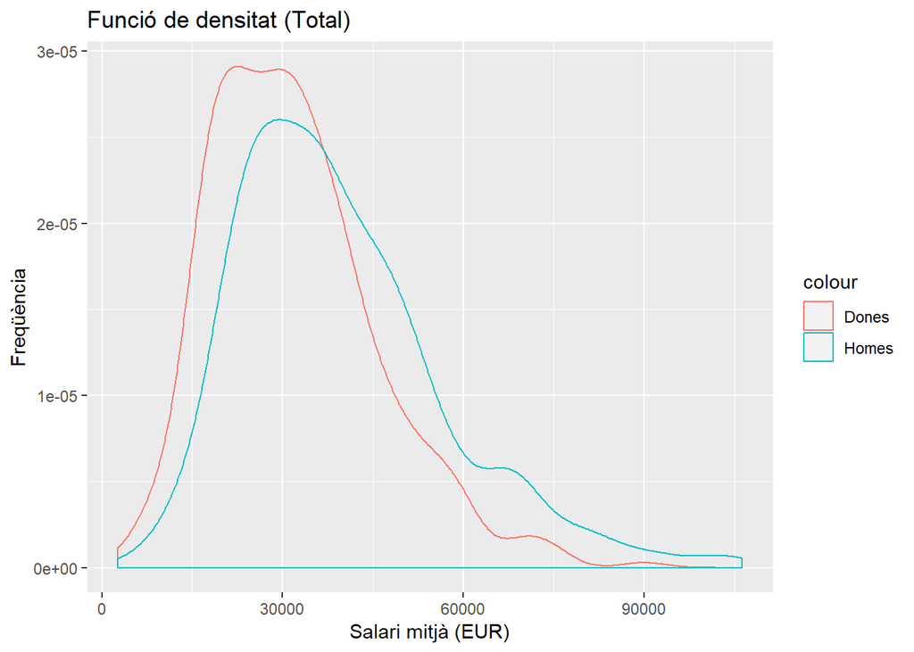

```r
ggplot(salaryGap) +
  xlab("Salari mitjà (EUR)") + ylab("Freqüència") + ggtitle("Funció de densitat (Total)") +
  geom_density(aes(x = WomenAverageAnnualSalaryEUR, color = "Dones")) +
  geom_density(aes(x = MenAverageAnnualSalaryEUR, color = "Homes"))
```

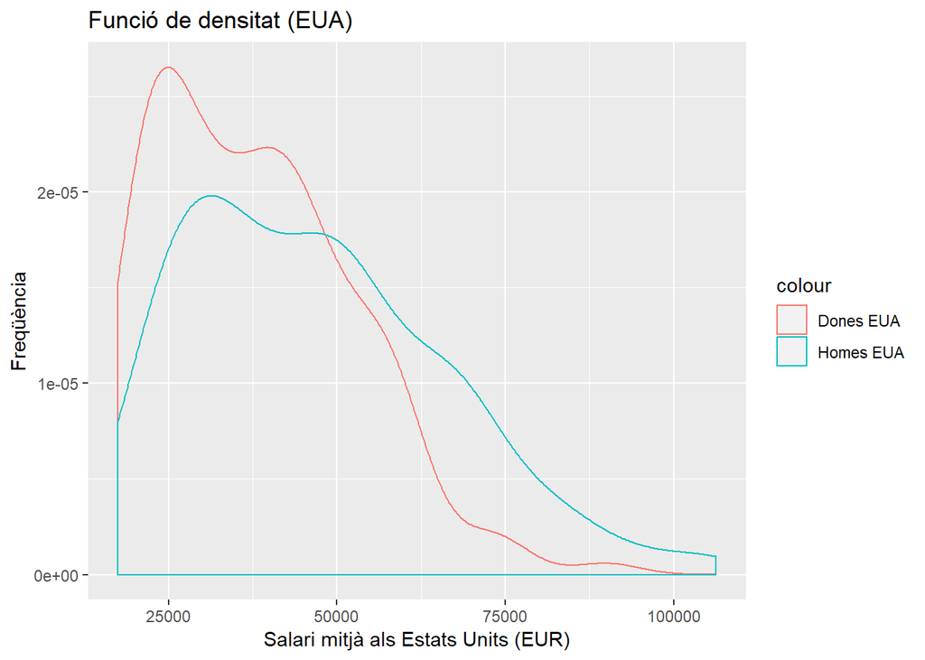

```r
ggplot(salaryGapUS) +
  xlab("Salari mitjà als Estats Units (EUR)") + ylab("Freqüència") + ggtitle("Funció de densitat (EUA)") +
  geom_density(aes(x = WomenAverageAnnualSalaryEUR, color = "Dones EUA")) +
  geom_density(aes(x = MenAverageAnnualSalaryEUR, color = "Homes EUA"))
```

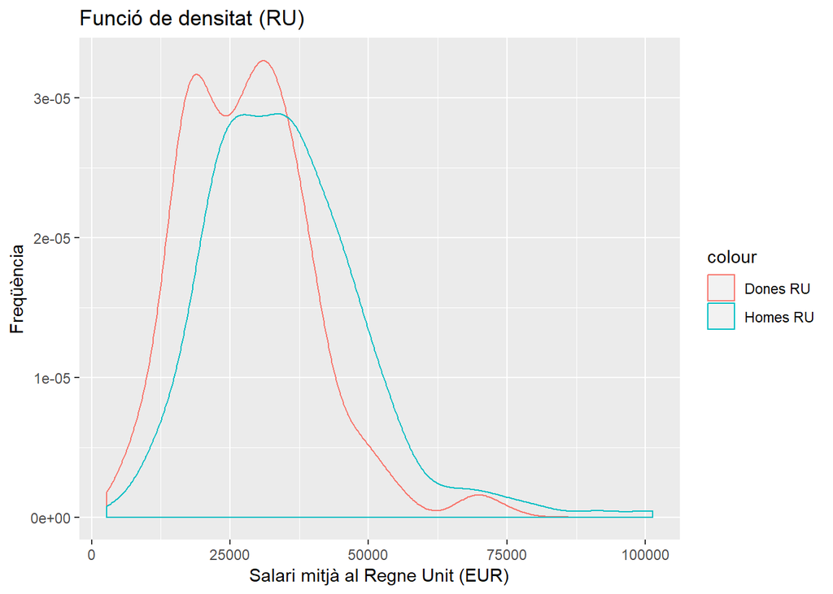

```r
ggplot(salaryGapUK) +
  xlab("Salari mitjà al Regne Unit (EUR)") + ylab("Freqüència") + ggtitle("Funció de densitat (RU)") +
  geom_density(aes(x = WomenAverageAnnualSalaryEUR, color = "Dones RU")) +
  geom_density(aes(x = MenAverageAnnualSalaryEUR, color = "Homes RU"))
```

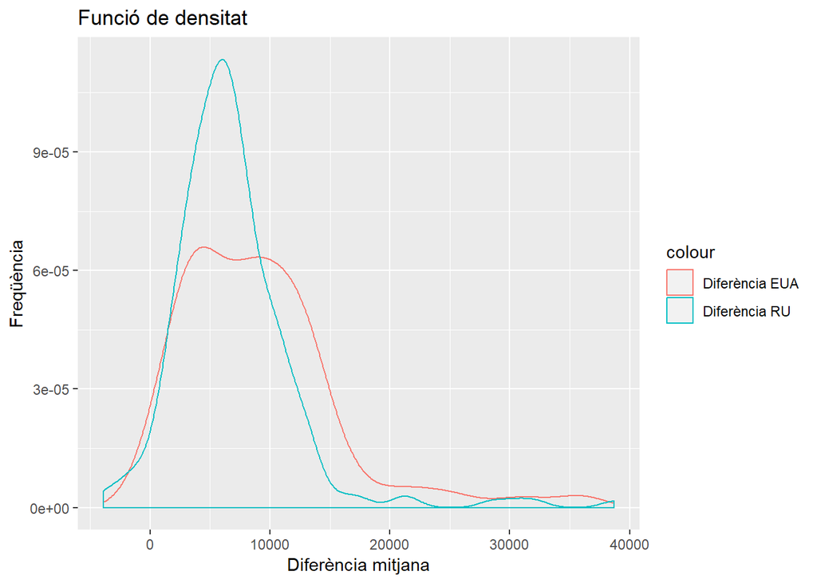

```r
par(mfrow=c(1,2))
ggplot() +
  xlab("Diferència mitjana") + ylab("Freqüència") + ggtitle("Funció de densitat") +
  geom_density(data=salaryGapUS, aes(x = salaryGapEUR, color = "Diferència EUA")) +
  geom_density(data=salaryGapUK, aes(x = salaryGapEUR, color = "Diferència RU"))
```

Com a curiositat, mostrem els valors (lloc de feina, categoria, paí, moneda, …) pels quals una dona guanya el mateix o més de mitja que un home; només hi ha 10 casos:

```r
salaryGapWM <- filter(salaryGap, WomenAverageAnnualSalary >= MenAverageAnnualSalary)
salaryGapWM <- select (salaryGapWM,
                       Occupation,  Category, Country,  Currency,
                       WomenAverageAnnualSalaryEUR, MenAverageAnnualSalaryEUR)
kable(salaryGapWM, caption = "Feines on les dones gunayen igual o més que els homes"
      ,col.names = c("Ocupació","Categoria","País", "Moneda", "Salari dones"
                     ,"Salari homes")
      ,align = c('r', 'r', 'r', 'r', 'r', 'r')
      , row.names = TRUE)
```

Feines on les dones gunayen igual o més que els homes

|  | Ocupació | Categoria | País | Moneda | Salari dones | Salari homes |
| --- | --- | --- | --- | --- | --- | --- |
| 1 | Stock clerks | sales & serving others | US | USD | 24322.48 | 23849.28 |
| 2 | Health technicians | science, tech & engineering | US | USD | 29243.76 | 29243.76 |
| 3 | Senior police | law & justice | UK | UKP | 70049.07 | 67510.17 |
| 4 | Traffic wardens | law & justice | UK | UKP | 23426.91 | 21797.10 |
| 5 | Valeters | sales & serving others | UK | UKP | 17764.11 | 17119.44 |
| 6 | Drivers | sales & serving others | UK | UKP | 48897.81 | 47382.66 |
| 7 | Train & tram drivers | sales & serving others | UK | UKP | 56653.74 | 56093.31 |
| 8 | Welfare officers | sales & serving others | UK | UKP | 34011.90 | 30091.23 |
| 9 | Town planners | science, tech & engineering | UK | UKP | 34144.11 | 32438.25 |
| 10 | IT directors | senior managers & execs | UK | UKP | 74093.76 | 70451.55 |

## Visualització sobre les dades. Un Dashboard o un conjunt de visualitzacions sobre els datasets escollits

```r
# Diferències totals
nrow(filter(salaryGap, salaryGapEUR <= 0))
```

```
## [1] 10
```

```r
nrow(filter(salaryGap, salaryGapEUR > 0 & salaryGapEUR <= 5000))
```

```
## [1] 122
```

```r
nrow(filter(salaryGap, salaryGapEUR > 5000 & salaryGapEUR <= 10000))
```

```
## [1] 151
```

```r
nrow(filter(salaryGap, salaryGapEUR > 10000 & salaryGapEUR <= 15000))
```

```
## [1] 71
```

```r
nrow(filter(salaryGap, salaryGapEUR > 15000))
```

```
## [1] 25
```

```r
# Diferències als EUA
nrow(filter(salaryGapUS, salaryGapEUR <= 0))
```

```
## [1] 2
```

```r
nrow(filter(salaryGapUS, salaryGapEUR > 0 & salaryGapEUR <= 5000))
```

```
## [1] 44
```

```r
nrow(filter(salaryGapUS, salaryGapEUR > 5000 & salaryGapEUR <= 10000))
```

```
## [1] 44
```

```r
nrow(filter(salaryGapUS, salaryGapEUR > 10000 & salaryGapEUR <= 15000))
```

```
## [1] 36
```

```r
nrow(filter(salaryGapUS, salaryGapEUR > 15000))
```

```
## [1] 16
```

```r
# Diferències as RU
nrow(filter(salaryGapUK, salaryGapEUR <= 0))
```

```
## [1] 8
```

```r
nrow(filter(salaryGapUK, salaryGapEUR > 0 & salaryGapEUR <= 5000))
```

```
## [1] 78
```

```r
nrow(filter(salaryGapUK, salaryGapEUR > 5000 & salaryGapEUR <= 10000))
```

```
## [1] 107
```

```r
nrow(filter(salaryGapUK, salaryGapEUR > 10000 & salaryGapEUR <= 15000))
```

```
## [1] 35
```

```r
nrow(filter(salaryGapUK, salaryGapEUR > 15000))
```

```
## [1] 9
```

```r
# Dades de les categories
salaryGapCategory <-
filter(salaryGap, tolower(as.character(Occupation)) == tolower(as.character(Category)))
salaryGapCategory <- select (salaryGapCategory,
                       Category, Country,   Currency,
                       WomenAverageAnnualSalaryEUR, MenAverageAnnualSalaryEUR
                       , salaryGapEUR, PayGapAsAPercentage)
salaryGapCategory <- arrange (salaryGapCategory, Country, Category)
kable(salaryGapCategory, caption = "Categories"
      ,col.names = c("Categoria","País", "Moneda", "Salari dones","Salari homes"
                     , "Diferència", "Diferència %")
      ,align = c('r', 'r', 'r', 'r', 'r', 'r')
      , row.names = TRUE)
```

Categories

|  | Categoria | País | Moneda | Salari dones | Salari homes | Diferència | Diferència % |
| --- | --- | --- | --- | --- | --- | --- | --- |
| 1 | admin & organisation | UK | UKP | 23844.60 | 29613.87 | 5769.27 | 0.2369 |
| 2 | care & education | UK | UKP | 28478.97 | 34602.75 | 6123.78 | 0.2110 |
| 3 | creative & media | UK | UKP | 30859.92 | 36948.60 | 6088.68 | 0.2119 |
| 4 | law & justice | UK | UKP | 33783.75 | 37200.15 | 3416.40 | 0.1193 |
| 5 | manual work | UK | UKP | 19320.21 | 26358.93 | 7038.72 | 0.3809 |
| 6 | sales & serving others | UK | UKP | 21608.73 | 26635.05 | 5026.32 | 0.2812 |
| 7 | science, tech & engineering | UK | UKP | 32556.42 | 39996.45 | 7440.03 | 0.2537 |
| 8 | senior managers & execs | UK | UKP | 37640.07 | 48002.76 | 10362.69 | 0.2823 |
| 9 | admin & organisation | US | USD | 37983.40 | 46708.48 | 8725.08 | 0.2102 |
| 10 | care & education | US | USD | 39982.67 | 48421.10 | 8438.43 | 0.2017 |
| 11 | creative & media | US | USD | 42114.80 | 51878.19 | 9763.39 | 0.2311 |
| 12 | law & justice | US | USD | 28756.91 | 36804.04 | 8047.13 | 0.2622 |
| 13 | manual work | US | USD | 22415.12 | 27720.42 | 5305.30 | 0.2382 |
| 14 | sales & serving others | US | USD | 31869.11 | 38856.09 | 6986.98 | 0.2155 |
| 15 | science, tech & engineering | US | USD | 46429.11 | 55561.87 | 9132.76 | 0.2046 |
| 16 | senior managers & execs | US | USD | 51763.53 | 71386.77 | 19623.24 | 0.3779 |

```r
# Top diferència
salaryGapTop <-
  filter(salaryGap, tolower(as.character(Occupation)) != tolower(as.character(Category)))
salaryGapTop <- select (salaryGapTop,
                       Occupation, Category, Country,
                       WomenAverageAnnualSalaryEUR,
                       MenAverageAnnualSalaryEUR, salaryGapEUR, PayGapAsAPercentage)
salaryGapTop <- arrange (salaryGapTop, desc(salaryGapEUR))
salaryGapTop <- head(salaryGapTop)
kable(salaryGapTop, caption = "Top diferències"
      ,col.names = c("Ocupació", "Categoria","País", "Salari dones","Salari homes",
                     "Diferència", "Diferència %")
      ,align = c('r', 'r', 'r', 'r', 'r', 'r')
      , row.names = TRUE)
```

Top diferències

|  | Ocupació | Categoria | País | Salari dones | Salari homes | Diferència | Diferència % |
| --- | --- | --- | --- | --- | --- | --- | --- |
| 1 | Medical practitioners | care & education | UK | 52597.35 | 91289.25 | 38691.90 | 0.7356 |
| 2 | Legal occupations | law & justice | US | 47367.32 | 83519.80 | 36152.48 | 0.7632 |
| 3 | Doctors & surgeons | care & education | US | 58960.72 | 94734.64 | 35773.92 | 0.6067 |
| 4 | CEOs | senior managers & execs | UK | 69086.16 | 101264.67 | 32178.51 | 0.4658 |
| 5 | Chief executives | senior managers & execs | US | 74387.04 | 106280.72 | 31893.68 | 0.4288 |
| 6 | Bank managers | senior managers & execs | UK | 43440.93 | 73865.61 | 30424.68 | 0.7004 |

```r
salaryGapTop <-
filter(salaryGap, tolower(as.character(Occupation)) != tolower(as.character(Category)))
salaryGapTop <- select (salaryGapTop,
                       Occupation, Category, Country,
                       WomenAverageAnnualSalaryEUR, MenAverageAnnualSalaryEUR,
                       salaryGapEUR, PayGapAsAPercentage)
salaryGapTop <- arrange (salaryGapTop, desc(PayGapAsAPercentage))
salaryGapTop <- head(salaryGapTop)
kable(salaryGapTop, caption = "Top diferències en percentatge"
      ,col.names = c("Ocupació", "Categoria","País", "Salari dones","Salari homes",
                     "Diferència", "Diferència %")
      ,align = c('r', 'r', 'r', 'r', 'r', 'r')
      , row.names = TRUE)
```

Top diferències en percentatge

|  | Ocupació | Categoria | País | Salari dones | Salari homes | Diferència | Diferència % |
| --- | --- | --- | --- | --- | --- | --- | --- |
| 1 | Cleaning occupations | sales & serving others | UK | 7305.48 | 13672.62 | 6367.14 | 0.8716 |
| 2 | Machine operatives | science, tech & engineering | UK | 16162.38 | 29577.60 | 13415.22 | 0.8300 |
| 3 | Legal occupations | law & justice | US | 47367.32 | 83519.80 | 36152.48 | 0.7632 |
| 4 | Medical practitioners | care & education | UK | 52597.35 | 91289.25 | 38691.90 | 0.7356 |
| 5 | Bank managers | senior managers & execs | UK | 43440.93 | 73865.61 | 30424.68 | 0.7004 |
| 6 | Metalwork | manual work | UK | 17636.58 | 29886.48 | 12249.90 | 0.6946 |

```r
salaryGapTop <-
filter(salaryGap, tolower(as.character(Occupation)) != tolower(as.character(Category)))

salaryGapTop <-
  filter(salaryGapTop, salaryGapEUR < 0)

salaryGapTop <- select (salaryGapTop,
                       Occupation, Country,
                       WomenAverageAnnualSalaryEUR, MenAverageAnnualSalaryEUR,
                       salaryGapEUR, PayGapAsAPercentage)

salaryGapTop <- arrange (salaryGapTop, salaryGapEUR)
kable(salaryGapTop, caption = "Diferències en favor de les dones"
      ,col.names = c("Ocupació", "País", "Salari dones","Salari homes",
                     "Diferència", "Diferència %")
      ,align = c('r', 'r', 'r', 'r', 'r', 'r')
      , row.names = TRUE)
```

Diferències en favor de les dones

|  | Ocupació | País | Salari dones | Salari homes | Diferència | Diferència % |
| --- | --- | --- | --- | --- | --- | --- |
| 1 | Welfare officers | UK | 34011.90 | 30091.23 | -3920.67 | -0.1153 |
| 2 | IT directors | UK | 74093.76 | 70451.55 | -3642.21 | -0.0492 |
| 3 | Senior police | UK | 70049.07 | 67510.17 | -2538.90 | -0.0362 |
| 4 | Town planners | UK | 34144.11 | 32438.25 | -1705.86 | -0.0500 |
| 5 | Traffic wardens | UK | 23426.91 | 21797.10 | -1629.81 | -0.0696 |
| 6 | Drivers | UK | 48897.81 | 47382.66 | -1515.15 | -0.0310 |
| 7 | Valeters | UK | 17764.11 | 17119.44 | -644.67 | -0.0363 |
| 8 | Train & tram drivers | UK | 56653.74 | 56093.31 | -560.43 | -0.0099 |
| 9 | Stock clerks | US | 24322.48 | 23849.28 | -473.20 | -0.0195 |

Finalment, desem el dataset:

```r
write.csv(salaryGap, file = "salaryGapFinal.csv")
```